# H4

## Parker Jenks | Collin Butterfield | Kasey Moynier

```python
import numpy as np
import pandas as pd
import matplotlib.pyplot as plt
import seaborn as sns
sns.set()
plt.style.use('fivethirtyeight')
import warnings
warnings.filterwarnings('ignore')
%matplotlib inline
```

```python
rand_state = 1000
```

```python
df = pd.read_csv("titanic_train.csv")
```

```python
dftest = pd.read_csv("titanic_test.csv")
```

```python
df.head()
```

|  | PassengerId | Survived | Pclass | Name | Sex | Age | SibSp | Parch | Ticket | Fare | Cabin | Embarked |
| --- | --- | --- | --- | --- | --- | --- | --- | --- | --- | --- | --- | --- |
| 0 | 1 | 0 | 3 | Braund, Mr. Owen Harris | male | 22.0 | 1 | 0 | A/5 21171 | 7.2500 | NaN | S |
| 1 | 2 | 1 | 1 | Cumings, Mrs. John Bradley (Florence Briggs Th... | female | 38.0 | 1 | 0 | PC 17599 | 71.2833 | C85 | C |
| 2 | 3 | 1 | 3 | Heikkinen, Miss. Laina | female | 26.0 | 0 | 0 | STON/O2. 3101282 | 7.9250 | NaN | S |
| 3 | 4 | 1 | 1 | Futrelle, Mrs. Jacques Heath (Lily May Peel) | female | 35.0 | 1 | 0 | 113803 | 53.1000 | C123 | S |
| 4 | 5 | 0 | 3 | Allen, Mr. William Henry | male | 35.0 | 0 | 0 | 373450 | 8.0500 | NaN | S |

```python
dftest.head()
```

|  | PassengerId | Pclass | Name | Sex | Age | SibSp | Parch | Ticket | Fare | Cabin | Embarked |
| --- | --- | --- | --- | --- | --- | --- | --- | --- | --- | --- | --- |
| 0 | 892 | 3 | Kelly, Mr. James | male | 34.5 | 0 | 0 | 330911 | 7.8292 | NaN | Q |
| 1 | 893 | 3 | Wilkes, Mrs. James (Ellen Needs) | female | 47.0 | 1 | 0 | 363272 | 7.0000 | NaN | S |
| 2 | 894 | 2 | Myles, Mr. Thomas Francis | male | 62.0 | 0 | 0 | 240276 | 9.6875 | NaN | Q |
| 3 | 895 | 3 | Wirz, Mr. Albert | male | 27.0 | 0 | 0 | 315154 | 8.6625 | NaN | S |
| 4 | 896 | 3 | Hirvonen, Mrs. Alexander (Helga E Lindqvist) | female | 22.0 | 1 | 1 | 3101298 | 12.2875 | NaN | S |

```python
df.info()
```

```
<class 'pandas.core.frame.DataFrame'>
RangeIndex: 891 entries, 0 to 890
Data columns (total 12 columns):
PassengerId    891 non-null int64
Survived       891 non-null int64
Pclass         891 non-null int64
Name           891 non-null object
Sex            891 non-null object
Age            714 non-null float64
SibSp          891 non-null int64
Parch          891 non-null int64
Ticket         891 non-null object
Fare           891 non-null float64
Cabin          204 non-null object
Embarked       889 non-null object
dtypes: float64(2), int64(5), object(5)
memory usage: 83.7+ KB
```

```python
df.isnull().sum()
```

```
PassengerId      0
Survived         0
Pclass           0
Name             0
Sex              0
Age            177
SibSp            0
Parch            0
Ticket           0
Fare             0
Cabin          687
Embarked         2
dtype: int64
```

Age, Cabin, and embarked need to be adjusted to compensate for the missing values.

# Data Observations:

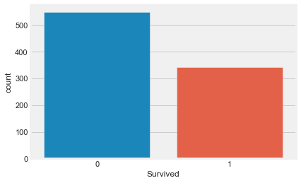

```python
ax = sns.countplot(x="Survived", data=df)
```

```python
sum(df['Survived'])/len(df)
```

```
0.3838383838383838
```

Only 38.4% of passengers actually survived the incident

```python
df.groupby(['Sex','Survived'])['Survived'].count()
```

```
Sex     Survived
female  0            81
        1           233
male    0           468
        1           109
Name: Survived, dtype: int64
```

```python
df.columns
```

```
Index(['PassengerId', 'Survived', 'Pclass', 'Name', 'Sex', 'Age', 'SibSp',
       'Parch', 'Ticket', 'Fare', 'Cabin', 'Embarked'],
      dtype='object')
```

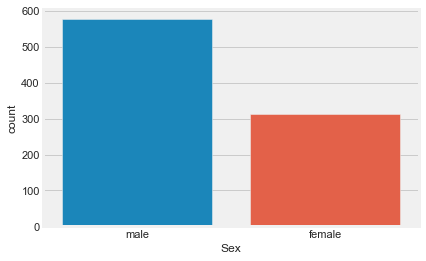

```python
ax = sns.countplot(x="Sex", data=df)
```

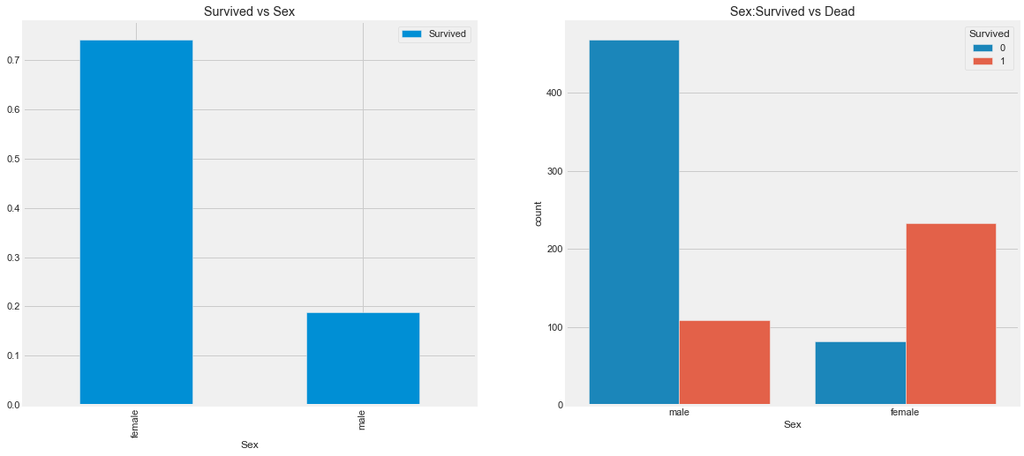

```python
f,ax=plt.subplots(1,2,figsize=(18,8))
df[['Sex','Survived']].groupby(['Sex']).mean().plot.bar(ax=ax[0])
ax[0].set_title('Survived vs Sex')
sns.countplot('Sex',hue='Survived',data=df,ax=ax[1])
ax[1].set_title('Sex:Survived vs Dead')
plt.show()
```

Females are in pretty good shape in this circumstance.

```python
pd.crosstab(df.Pclass,df.Survived,margins=True).style.background_gradient(cmap='summer_r')
```

| Survived Pclass | 0 | 1 | All |
| --- | --- | --- | --- |
| 1 | 80 | 136 | 216 |
| 2 | 97 | 87 | 184 |
| 3 | 372 | 119 | 491 |
| All | 549 | 342 | 891 |

Those in the 3rd class were greatly impacted by the incident. A majority of these passengers died.

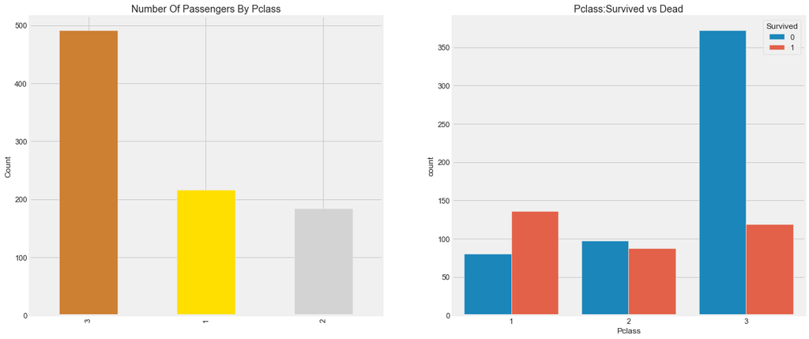

```python
f,ax=plt.subplots(1,2,figsize=(18,8))
df['Pclass'].value_counts().plot.bar(color=['#CD7F32','#FFDF00','#D3D3D3'],ax=ax[0])
ax[0].set_title('Number Of Passengers By Pclass')
ax[0].set_ylabel('Count')
sns.countplot('Pclass',hue='Survived',data=df,ax=ax[1])
ax[1].set_title('Pclass:Survived vs Dead')
plt.show()
```

```python
pd.crosstab([df.Sex,df.Survived],df.Pclass,margins=True).style.background_gradient(cmap='summer_r')
```

| Sex | Pclass Survived | 1 | 2 | 3 | All |
| --- | --- | --- | --- | --- | --- |
| female | 0 | 3 | 6 | 72 | 81 |
|  | 1 | 91 | 70 | 72 | 233 |
| male | 0 | 77 | 91 | 300 | 468 |
|  | 1 | 45 | 17 | 47 | 109 |
| All |  | 216 | 184 | 491 | 891 |

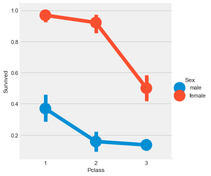

```python
sns.factorplot('Pclass','Survived',hue='Sex',data=df)
plt.show()
```

All those in class three experienced a much lower chance of survival when copared to the other classes.

Nearly all women in class 1 survived. We can see here there was upwards of an 97-98% survival rate.

```python
print('Oldest Passenger was of:',df['Age'].max(),'Years')
print('Youngest Passenger was of:',df['Age'].min(),'Years')
print('Average Age on the ship:',df['Age'].mean(),'Years')
```

```
Oldest Passenger was of: 80.0 Years
Youngest Passenger was of: 0.42 Years
Average Age on the ship: 29.69911764705882 Years
```

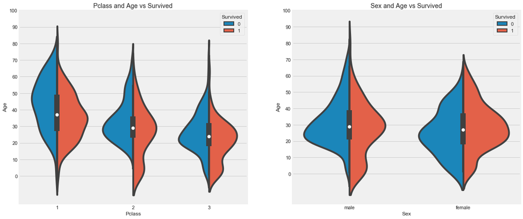

```python
f,ax=plt.subplots(1,2,figsize=(18,8))
sns.violinplot("Pclass","Age", hue="Survived", data=df,split=True,ax=ax[0])
ax[0].set_title('Pclass and Age vs Survived')
ax[0].set_yticks(range(0,110,10))
sns.violinplot("Sex","Age", hue="Survived", data=df,split=True,ax=ax[1])
ax[1].set_title('Sex and Age vs Survived')
ax[1].set_yticks(range(0,110,10))
plt.show()
```

# Replacing NA Values

```python
df['Initial']=0
for i in df:
    df['Initial']=df.Name.str.extract('([A-Za-z]+)\.') #lets extract the Salutations
```

```python
pd.crosstab(df.Initial,df.Sex).T.style.background_gradient(cmap='summer_r') #Checking the Initials with the Sex
```

| Initial Sex | Capt | Col | Countess | Don | Dr | Jonkheer | Lady | Major | Master | Miss | Mlle | Mme | Mr | Mrs | Ms | Rev | Sir |
| --- | --- | --- | --- | --- | --- | --- | --- | --- | --- | --- | --- | --- | --- | --- | --- | --- | --- |
| female | 0 | 0 | 1 | 0 | 1 | 0 | 1 | 0 | 0 | 182 | 2 | 1 | 0 | 125 | 1 | 0 | 0 |
| male | 1 | 2 | 0 | 1 | 6 | 1 | 0 | 2 | 40 | 0 | 0 | 0 | 517 | 0 | 0 | 6 | 1 |

```python
df['Initial'].replace(
    ['Mlle','Mme','Ms','Dr','Major','Lady','Countess',
     'Jonkheer','Col','Rev','Capt','Sir','Don'],
    ['Miss','Miss','Miss','Mr','Mr','Mrs','Mrs','Other','Other','Other','Mr','Mr','Mr'],inplace=True)
```

```python
pd.crosstab(df.Initial,df.Sex).T.style.background_gradient(cmap='summer_r')
```

| Initial Sex | Master | Miss | Mr | Mrs | Other |
| --- | --- | --- | --- | --- | --- |
| female | 0 | 186 | 1 | 127 | 0 |
| male | 40 | 0 | 528 | 0 | 9 |

```python
df.groupby('Initial')['Age'].mean()
```

```
Initial
Master     4.574167
Miss      21.860000
Mr        32.739609
Mrs       35.981818
Other     45.888889
Name: Age, dtype: float64
```

```python
df.loc[(df.Age.isnull())&(df.Initial=='Mr'),'Age']=33
df.loc[(df.Age.isnull())&(df.Initial=='Mrs'),'Age']=36
df.loc[(df.Age.isnull())&(df.Initial=='Master'),'Age']=5
df.loc[(df.Age.isnull())&(df.Initial=='Miss'),'Age']=22
df.loc[(df.Age.isnull())&(df.Initial=='Other'),'Age']=46
```

```python
df.isnull().sum()
```

```
PassengerId      0
Survived         0
Pclass           0
Name             0
Sex              0
Age              0
SibSp            0
Parch            0
Ticket           0
Fare             0
Cabin          687
Embarked         2
Initial          0
dtype: int64
```

```python
df.Age.isnull().any() #So no null values left finally
```

```
False
```

# Adjusting Null Values Test Set

```python
dftest['Initial']=0
for i in dftest:
    dftest['Initial']=dftest.Name.str.extract('([A-Za-z]+)\.') #lets extract the Salutations
```

```python
pd.crosstab(dftest.Initial,dftest.Sex).T.style.background_gradient(cmap='summer_r') #Checking the Initials with the Sex
```

| Initial Sex | Col | Dona | Dr | Master | Miss | Mr | Mrs | Ms | Rev |
| --- | --- | --- | --- | --- | --- | --- | --- | --- | --- |
| female | 0 | 1 | 0 | 0 | 78 | 0 | 72 | 1 | 0 |
| male | 2 | 0 | 1 | 21 | 0 | 240 | 0 | 0 | 2 |

```python
dftest['Initial'].replace(
    ['Mlle','Mme','Ms','Dr','Major','Lady','Countess',
     'Jonkheer','Col','Rev','Capt','Sir','Don','Dona'],
    ['Miss','Miss','Miss','Mr','Mr','Mrs','Mrs','Other','Other','Other','Mr','Mr','Mr','Other'],inplace=True)
```

```python
dftest.loc[(dftest.Age.isnull())&(dftest.Initial=='Mr'),'Age']=33
dftest.loc[(dftest.Age.isnull())&(dftest.Initial=='Mrs'),'Age']=36
dftest.loc[(dftest.Age.isnull())&(dftest.Initial=='Master'),'Age']=5
dftest.loc[(dftest.Age.isnull())&(dftest.Initial=='Miss'),'Age']=22
dftest.loc[(dftest.Age.isnull())&(dftest.Initial=='Other'),'Age']=46
```

```python
dftest.isnull().sum()
```

```
PassengerId      0
Pclass           0
Name             0
Sex              0
Age              0
SibSp            0
Parch            0
Ticket           0
Fare             1
Cabin          327
Embarked         0
Initial          0
dtype: int64
```

# Passenger Class Analysis

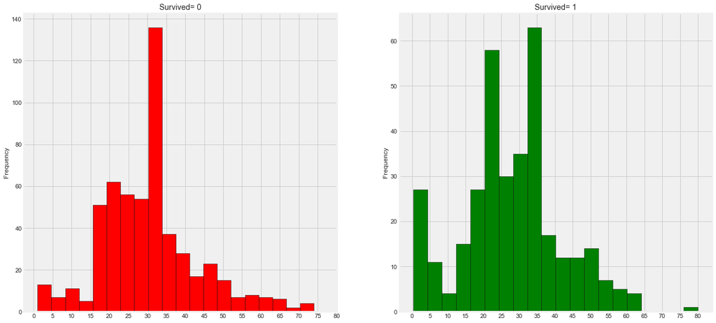

```python
f,ax=plt.subplots(1,2,figsize=(20,10))
df[df['Survived']==0].Age.plot.hist(ax=ax[0],bins=20,edgecolor='black',color='red')
ax[0].set_title('Survived= 0')
x1=list(range(0,85,5))
ax[0].set_xticks(x1)
df[df['Survived']==1].Age.plot.hist(ax=ax[1],color='green',bins=20,edgecolor='black')
ax[1].set_title('Survived= 1')
x2=list(range(0,85,5))
ax[1].set_xticks(x2)
plt.show()
```

A majority of the children under 5 were saved in the accident

The oldest passenger saved was 80. the next oldest passenger who survived was somewhere between 60-65. Props to that guy for surviving.

20-25 and 30-35 saw the most survivors. However, the most deaths seen was in the 30-35 age group. Probably because that was close to the mean age. Also because maybe those people were stalwart and sacrificed themselves to save others. I'm gonna go with the latter.

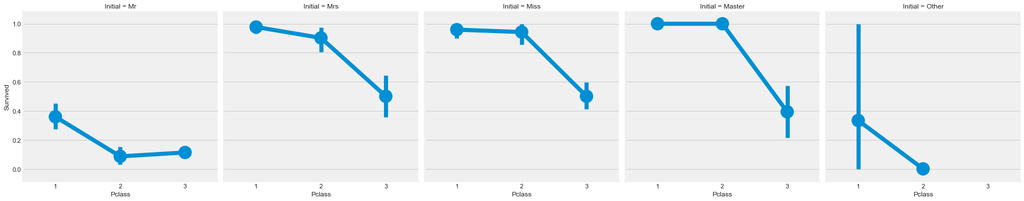

```python
sns.factorplot('Pclass','Survived',col='Initial',data=df)
plt.show()
```

Men in general had a really low chance of survival unfortunately... At least the men with the title of "Mr."

```python
# A great table that shows the overall relationship between embak points, classes, and sex.
pd.crosstab([df.Embarked,df.Pclass],[df.Sex,df.Survived],
            margins=True).style.background_gradient(cmap='summer_r')
```

| Embarked | Sex Survived Pclass | female 0 | female 1 | male 0 | male 1 | All |
| --- | --- | --- | --- | --- | --- | --- |
| C | 1 | 1 | 42 | 25 | 17 | 85 |
|  | 2 | 0 | 7 | 8 | 2 | 17 |
|  | 3 | 8 | 15 | 33 | 10 | 66 |
| Q | 1 | 0 | 1 | 1 | 0 | 2 |
|  | 2 | 0 | 2 | 1 | 0 | 3 |
|  | 3 | 9 | 24 | 36 | 3 | 72 |
| S | 1 | 2 | 46 | 51 | 28 | 127 |
|  | 2 | 6 | 61 | 82 | 15 | 164 |
|  | 3 | 55 | 33 | 231 | 34 | 353 |
| All |  | 81 | 231 | 468 | 109 | 889 |

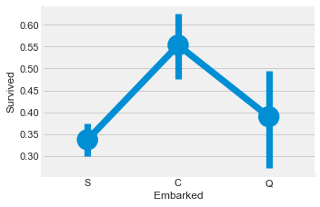

```python
sns.factorplot('Embarked','Survived',data=df)
fig=plt.gcf()
fig.set_size_inches(5,3)
plt.show()
```

Those passengers who embarked from Cherburg are the ones who have the highest chances of survival at about 55% chance.

But why?...

In my humble opinion, I would say it is because a majority of passengers that embarked from Cherburg were first class while a majority in port Queenstown were class 3.

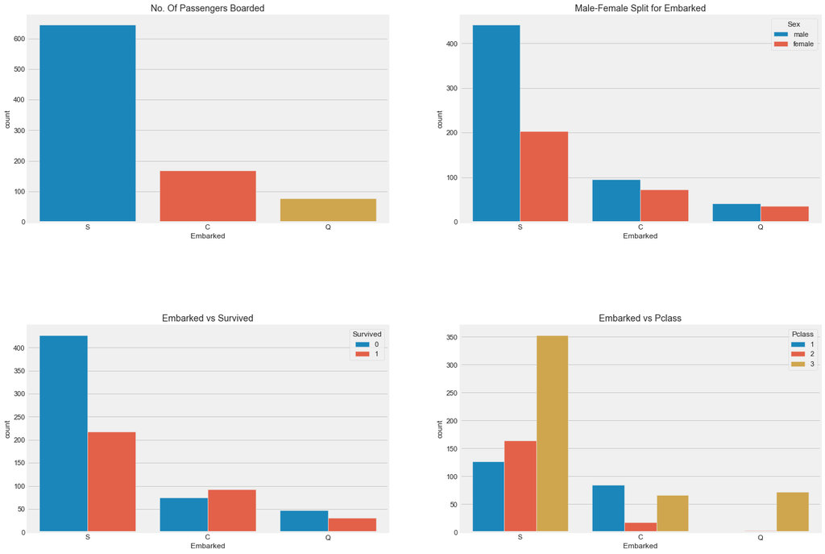

```python
f,ax=plt.subplots(2,2,figsize=(20,15))
sns.countplot('Embarked',data=df,ax=ax[0,0])
ax[0,0].set_title('No. Of Passengers Boarded')
sns.countplot('Embarked',hue='Sex',data=df,ax=ax[0,1])
ax[0,1].set_title('Male-Female Split for Embarked')
sns.countplot('Embarked',hue='Survived',data=df,ax=ax[1,0])
ax[1,0].set_title('Embarked vs Survived')
sns.countplot('Embarked',hue='Pclass',data=df,ax=ax[1,1])
ax[1,1].set_title('Embarked vs Pclass')
plt.subplots_adjust(wspace=0.2,hspace=0.5)
plt.show()
```

1. In general, more males than females are boarding at all three ports. The largest disparity appears to be at port S.
2. A majority of port C embarkers were first class. That is probably why Port C was the only one that saw a majority survival rate.
3. Port Q didn't stand a chance with how many class 3 embarkers there were. That's rough...

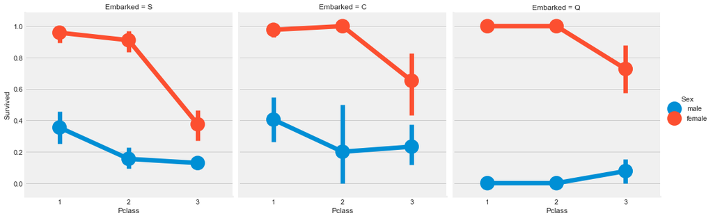

```python
sns.factorplot('Pclass','Survived',hue='Sex',col='Embarked',data=df)
plt.show()
```

There was a similar trend across males in all three classes and ports.

```python
df.isnull().sum()
```

```
PassengerId      0
Survived         0
Pclass           0
Name             0
Sex              0
Age              0
SibSp            0
Parch            0
Ticket           0
Fare             0
Cabin          687
Embarked         2
Initial          0
dtype: int64
```

```python
df['Embarked'].fillna('S',inplace=True)
```

```python
#Applying same adjustment to the test set
dftest['Embarked'].fillna('S',inplace=True)
```

```python
df.isnull().sum(0)
```

```
PassengerId      0
Survived         0
Pclass           0
Name             0
Sex              0
Age              0
SibSp            0
Parch            0
Ticket           0
Fare             0
Cabin          687
Embarked         0
Initial          0
dtype: int64
```

```python
df.Embarked.isnull().any()# Finally No NaN values
```

```
False
```

```python
dftest.Embarked.isnull().any()# Finally No NaN values
```

```
False
```

# Sibling Analysis

SibSp shows how many siblings/spouses the person was travelling with. Siblings include brother, sister, step sister, step brother, and step sister.

Obviously, spouse is referring to a husband or wife

```python
pd.crosstab([df.SibSp],df.Survived).style.background_gradient(cmap='summer_r')
```

| Survived SibSp | 0 | 1 |
| --- | --- | --- |
| 0 | 398 | 210 |
| 1 | 97 | 112 |
| 2 | 15 | 13 |
| 3 | 12 | 4 |
| 4 | 15 | 3 |
| 5 | 5 | 0 |
| 8 | 7 | 0 |

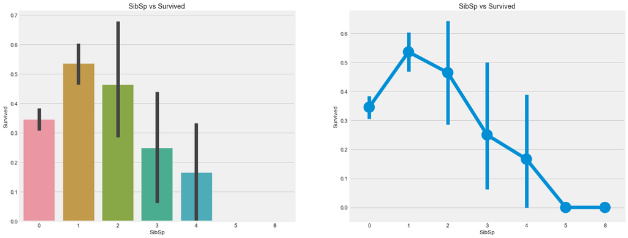

```python
f,ax=plt.subplots(1,2,figsize=(20,8))
sns.barplot('SibSp','Survived',data=df,ax=ax[0])
ax[0].set_title('SibSp vs Survived')
sns.factorplot('SibSp','Survived',data=df,ax=ax[1])
ax[1].set_title('SibSp vs Survived')
plt.close(2)
plt.show()
```

1. The people with a large number of siblings/family members had an extremely low survival rate.
2. The best spot to be was have 1-2 siblings or spouse. A likely combination would be husband wife and a child.
3. Someone with just one sibling/spouse with them had the highest survival chances. Experiencing this disaster with a sibling and friend is likely what pushed some of these people to survive.

```python
pd.crosstab([df.SibSp],df.Pclass).style.background_gradient(cmap='summer_r')
```

| Pclass SibSp | 1 | 2 | 3 |
| --- | --- | --- | --- |
| 0 | 137 | 120 | 351 |
| 1 | 71 | 55 | 83 |
| 2 | 5 | 8 | 15 |
| 3 | 3 | 1 | 12 |
| 4 | 0 | 0 | 18 |
| 5 | 0 | 0 | 5 |
| 8 | 0 | 0 | 7 |

Not suprising, it looks like families with over four people all purchased class 3 tickets.

# Parent Child Analysis (Parch)

```python
pd.crosstab(df.Parch,df.Pclass).style.background_gradient(cmap='summer_r')
```

| Pclass Parch | 1 | 2 | 3 |
| --- | --- | --- | --- |
| 0 | 163 | 134 | 381 |
| 1 | 31 | 32 | 55 |
| 2 | 21 | 16 | 43 |
| 3 | 0 | 2 | 3 |
| 4 | 1 | 0 | 3 |
| 5 | 0 | 0 | 5 |
| 6 | 0 | 0 | 1 |

Similar to past observations, most families purchased class 3 tickets.

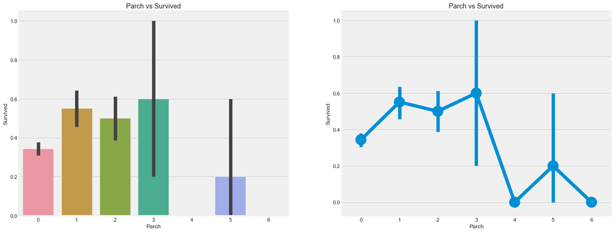

```python
f,ax=plt.subplots(1,2,figsize=(20,8))
sns.barplot('Parch','Survived',data=df,ax=ax[0])
ax[0].set_title('Parch vs Survived')
sns.factorplot('Parch','Survived',data=df,ax=ax[1])
ax[1].set_title('Parch vs Survived')
plt.close(2)
plt.show()
```

Survival appears to be best for families of 3. However the range of survival probability is extreme. A similar range can be seen among families of 5.

```python
print('Highest Fare was:',df['Fare'].max())
print('Lowest Fare was:',df['Fare'].min())
print('Average Fare was:',df['Fare'].mean())
```

```
Highest Fare was: 512.3292
Lowest Fare was: 0.0
Average Fare was: 32.2042079685746
```

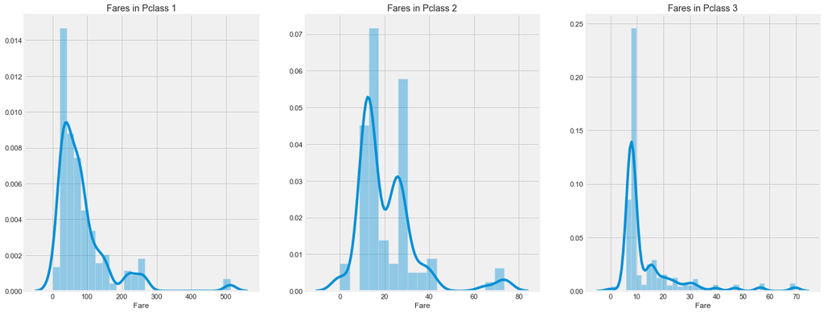

```python
f,ax=plt.subplots(1,3,figsize=(20,8))
sns.distplot(df[df['Pclass']==1].Fare,ax=ax[0])
ax[0].set_title('Fares in Pclass 1')
sns.distplot(df[df['Pclass']==2].Fare,ax=ax[1])
ax[1].set_title('Fares in Pclass 2')
sns.distplot(df[df['Pclass']==3].Fare,ax=ax[2])
ax[2].set_title('Fares in Pclass 3')
plt.show()
```

# Correlations

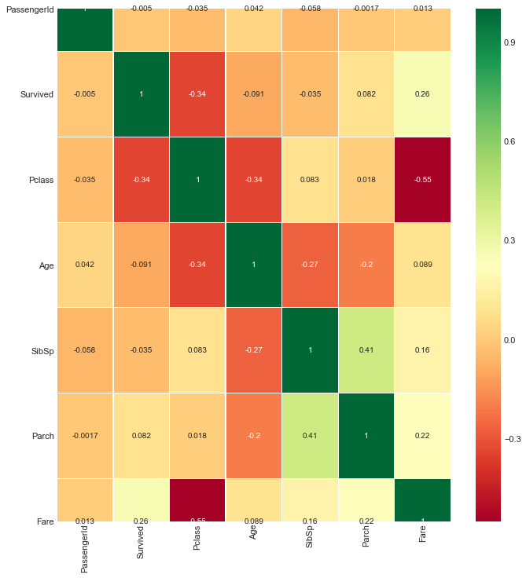

```python
sns.heatmap(df.corr(),annot=True,cmap='RdYlGn',linewidths=0.2) #data.corr()-->correlation matrix
fig=plt.gcf()
fig.set_size_inches(10,12)
plt.show()
```

1. In my opinion, there is nothing of particular note from this graph. One thing to be aware of is that there is a -0.34 correlation between survival and passenger class. Basically, as passenger class rises (from class 1 to class 2 or 3), the chances of survival decrease.

# Feature Engineering:

```python
df['Age_band']=0
df.loc[df['Age']<=16,'Age_band']=0
df.loc[(df['Age']>16)&(df['Age']<=32),'Age_band']=1
df.loc[(df['Age']>32)&(df['Age']<=48),'Age_band']=2
df.loc[(df['Age']>48)&(df['Age']<=64),'Age_band']=3
df.loc[df['Age']>64,'Age_band']=4
df.head(2)
```

|  | PassengerId | Survived | Pclass | Name | Sex | Age | SibSp | Parch | Ticket | Fare | Cabin | Embarked | Initial | Age_band |
| --- | --- | --- | --- | --- | --- | --- | --- | --- | --- | --- | --- | --- | --- | --- |
| 0 | 1 | 0 | 3 | Braund, Mr. Owen Harris | male | 22.0 | 1 | 0 | A/5 21171 | 7.2500 | NaN | S | Mr | 1 |
| 1 | 2 | 1 | 1 | Cumings, Mrs. John Bradley (Florence Briggs Th... | female | 38.0 | 1 | 0 | PC 17599 | 71.2833 | C85 | C | Mrs | 2 |

```python
#Applying adjustments to test set

dftest['Age_band']=0
dftest.loc[dftest['Age']<=16,'Age_band']=0
dftest.loc[(dftest['Age']>16)&(dftest['Age']<=32),'Age_band']=1
dftest.loc[(dftest['Age']>32)&(dftest['Age']<=48),'Age_band']=2
dftest.loc[(dftest['Age']>48)&(dftest['Age']<=64),'Age_band']=3
dftest.loc[dftest['Age']>64,'Age_band']=4
dftest.head(2)
```

|  | PassengerId | Pclass | Name | Sex | Age | SibSp | Parch | Ticket | Fare | Cabin | Embarked | Initial | Age_band |
| --- | --- | --- | --- | --- | --- | --- | --- | --- | --- | --- | --- | --- | --- |
| 0 | 892 | 3 | Kelly, Mr. James | male | 34.5 | 0 | 0 | 330911 | 7.8292 | NaN | Q | Mr | 2 |
| 1 | 893 | 3 | Wilkes, Mrs. James (Ellen Needs) | female | 47.0 | 1 | 0 | 363272 | 7.0000 | NaN | S | Mrs | 2 |

```python
df['Age_band'].value_counts().to_frame().style.background_gradient(cmap='summer')#checking the number of passenegers in each band
```

|  | Age_band |
| --- | --- |
| 1 | 382 |
| 2 | 325 |
| 0 | 104 |
| 3 | 69 |
| 4 | 11 |

```python
df['Age_band'].mean()
```

```
1.4399551066217733
```

```python
df['Age_band'].describe()
```

```
count    891.000000
mean       1.439955
std        0.842373
min        0.000000
25%        1.000000
50%        1.000000
75%        2.000000
max        4.000000
Name: Age_band, dtype: float64
```

The variable is deinitely right skewed

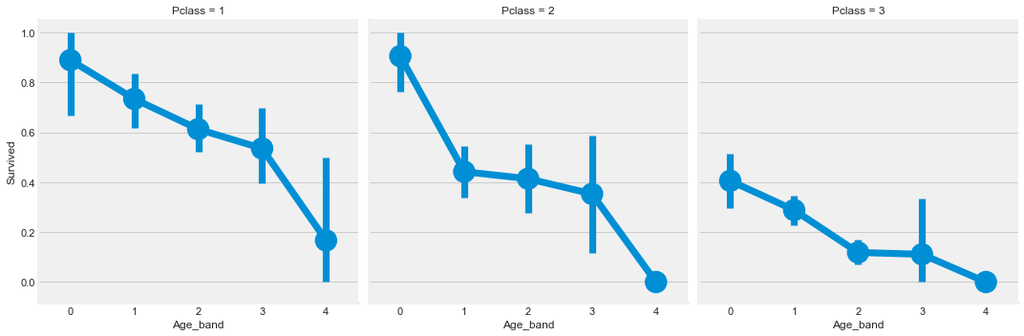

```python
sns.factorplot('Age_band','Survived',data=df,col='Pclass')
plt.show()
```

Those between the ages of 0-16 are the most likely to survive. Strangely enough, there is not a large discrpency between young passengers in class 1 or class 2.

Unfortunately, chances are low for all passengers between the ages of 64-80.

Those in class three have a significantly lower chance of survival compared to the other two classes.

# Family Size Analysis

```python
df['Family_Size']=0
df['Family_Size']=df['Parch']+df['SibSp']#family size
df['Alone']=0
df.loc[df.Family_Size==0,'Alone']=1#Alone

df.head()
```

|  | PassengerId | Survived | Pclass | Name | Sex | Age | SibSp | Parch | Ticket | Fare | Cabin | Embarked | Initial | Age_band | Family_Size | Alone |
| --- | --- | --- | --- | --- | --- | --- | --- | --- | --- | --- | --- | --- | --- | --- | --- | --- |
| 0 | 1 | 0 | 3 | Braund, Mr. Owen Harris | male | 22.0 | 1 | 0 | A/5 21171 | 7.2500 | NaN | S | Mr | 1 | 1 | 0 |
| 1 | 2 | 1 | 1 | Cumings, Mrs. John Bradley (Florence Briggs Th... | female | 38.0 | 1 | 0 | PC 17599 | 71.2833 | C85 | C | Mrs | 2 | 1 | 0 |
| 2 | 3 | 1 | 3 | Heikkinen, Miss. Laina | female | 26.0 | 0 | 0 | STON/O2. 3101282 | 7.9250 | NaN | S | Miss | 1 | 0 | 1 |
| 3 | 4 | 1 | 1 | Futrelle, Mrs. Jacques Heath (Lily May Peel) | female | 35.0 | 1 | 0 | 113803 | 53.1000 | C123 | S | Mrs | 2 | 1 | 0 |
| 4 | 5 | 0 | 3 | Allen, Mr. William Henry | male | 35.0 | 0 | 0 | 373450 | 8.0500 | NaN | S | Mr | 2 | 0 | 1 |

```python
dftest['Family_Size']=0
dftest['Family_Size']=dftest['Parch']+dftest['SibSp']#family size
dftest['Alone']=0
dftest.loc[dftest.Family_Size==0,'Alone']=1#Alone
```

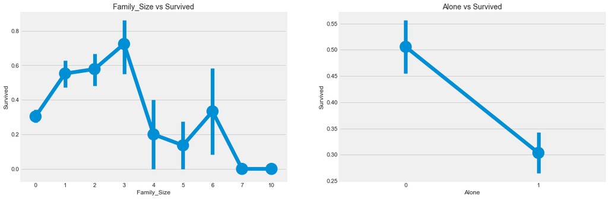

```python
f,ax=plt.subplots(1,2,figsize=(18,6))
sns.factorplot('Family_Size','Survived',data=df,ax=ax[0])
ax[0].set_title('Family_Size vs Survived')
sns.factorplot('Alone','Survived',data=df,ax=ax[1])
ax[1].set_title('Alone vs Survived')
plt.close(2)
plt.close(3)
plt.show()
```

IMPORTANT: Pay close attention to the y-axis on both of the graphs. Those with a family size of three have the highest rates of survival.

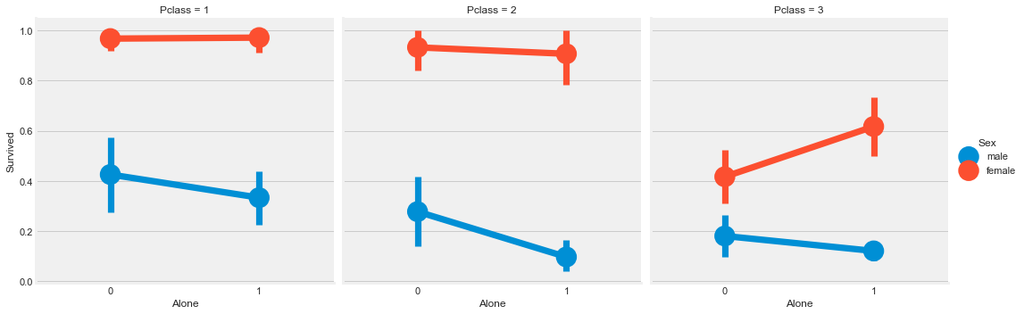

```python
sns.factorplot('Alone','Survived',data=df,hue='Sex',col='Pclass')
plt.show()
```

Women in class 1 and class 2 are not face the same survival rates regardless of whether they are alone or not.

```python
df.head()
```

|  | PassengerId | Survived | Pclass | Name | Sex | Age | SibSp | Parch | Ticket | Fare | Cabin | Embarked | Initial | Age_band | Family_Size | Alone |
| --- | --- | --- | --- | --- | --- | --- | --- | --- | --- | --- | --- | --- | --- | --- | --- | --- |
| 0 | 1 | 0 | 3 | Braund, Mr. Owen Harris | male | 22.0 | 1 | 0 | A/5 21171 | 7.2500 | NaN | S | Mr | 1 | 1 | 0 |
| 1 | 2 | 1 | 1 | Cumings, Mrs. John Bradley (Florence Briggs Th... | female | 38.0 | 1 | 0 | PC 17599 | 71.2833 | C85 | C | Mrs | 2 | 1 | 0 |
| 2 | 3 | 1 | 3 | Heikkinen, Miss. Laina | female | 26.0 | 0 | 0 | STON/O2. 3101282 | 7.9250 | NaN | S | Miss | 1 | 0 | 1 |
| 3 | 4 | 1 | 1 | Futrelle, Mrs. Jacques Heath (Lily May Peel) | female | 35.0 | 1 | 0 | 113803 | 53.1000 | C123 | S | Mrs | 2 | 1 | 0 |
| 4 | 5 | 0 | 3 | Allen, Mr. William Henry | male | 35.0 | 0 | 0 | 373450 | 8.0500 | NaN | S | Mr | 2 | 0 | 1 |

# Fare Analysis

```python
df['Fare_Range']=pd.qcut(df['Fare'],4)
df.groupby(['Fare_Range'])['Survived'].mean().to_frame().style.background_gradient(cmap='summer_r')
```

| Fare_Range | Survived |
| --- | --- |
| (-0.001, 7.91] | 0.197309 |
| (7.91, 14.454] | 0.303571 |
| (14.454, 31.0] | 0.454955 |
| (31.0, 512.329] | 0.581081 |

This is not particularly surprising, those whoe paid more for a ticket are more likely to survive the accient.

```python
# Splitting fare rate into multiple groups
df['Fare_cat']=0
df.loc[df['Fare']<=7.91,'Fare_cat']=0
df.loc[(df['Fare']>7.91)&(df['Fare']<=14.454),'Fare_cat']=1
df.loc[(df['Fare']>14.454)&(df['Fare']<=31),'Fare_cat']=2
df.loc[(df['Fare']>31)&(df['Fare']<=513),'Fare_cat']=3
```

```python
#Splitting fare rate on test test
dftest['Fare_cat']=0
dftest.loc[dftest['Fare']<=7.91,'Fare_cat']=0
dftest.loc[(dftest['Fare']>7.91)&(dftest['Fare']<=14.454),'Fare_cat']=1
dftest.loc[(dftest['Fare']>14.454)&(dftest['Fare']<=31),'Fare_cat']=2
dftest.loc[(dftest['Fare']>31)&(dftest['Fare']<=513),'Fare_cat']=3
```

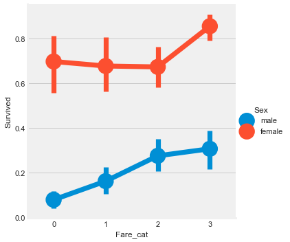

```python
sns.factorplot('Fare_cat','Survived',data=df,hue='Sex')
plt.show()
```

Women don't see a significant survival rate increase based on the amount they pay for their ticket. However, men see a steady rise in survival probability based on the amount paid for a ticket.

# Converting Strings to Numeric

```python
df['Sex'].replace(['male','female'],[0,1],inplace=True)
df['Embarked'].replace(['S','C','Q'],[0,1,2],inplace=True)
df['Initial'].replace(['Mr','Mrs','Miss','Master','Other'],[0,1,2,3,4],inplace=True)
```

```python
dftest.info()
```

```
<class 'pandas.core.frame.DataFrame'>
RangeIndex: 418 entries, 0 to 417
Data columns (total 16 columns):
PassengerId    418 non-null int64
Pclass         418 non-null int64
Name           418 non-null object
Sex            418 non-null object
Age            418 non-null float64
SibSp          418 non-null int64
Parch          418 non-null int64
Ticket         418 non-null object
Fare           417 non-null float64
Cabin          91 non-null object
Embarked       418 non-null object
Initial        418 non-null object
Age_band       418 non-null int64
Family_Size    418 non-null int64
Alone          418 non-null int64
Fare_cat       418 non-null int64
dtypes: float64(2), int64(8), object(6)
memory usage: 52.4+ KB
```

```python
# Same code on test set
dftest['Sex'].replace(['male','female'],[0,1],inplace=True)
dftest['Embarked'].replace(['S','C','Q'],[0,1,2],inplace=True)
dftest['Initial'].replace(['Mr','Mrs','Miss','Master','Other'],[0,1,2,3,4],inplace=True)
```

```python
dftest.head()
```

|  | PassengerId | Pclass | Name | Sex | Age | SibSp | Parch | Ticket | Fare | Cabin | Embarked | Initial | Age_band | Family_Size | Alone | Fare_cat |
| --- | --- | --- | --- | --- | --- | --- | --- | --- | --- | --- | --- | --- | --- | --- | --- | --- |
| 0 | 892 | 3 | Kelly, Mr. James | 0 | 34.5 | 0 | 0 | 330911 | 7.8292 | NaN | 2 | 0 | 2 | 0 | 1 | 0 |
| 1 | 893 | 3 | Wilkes, Mrs. James (Ellen Needs) | 1 | 47.0 | 1 | 0 | 363272 | 7.0000 | NaN | 0 | 1 | 2 | 1 | 0 | 0 |
| 2 | 894 | 2 | Myles, Mr. Thomas Francis | 0 | 62.0 | 0 | 0 | 240276 | 9.6875 | NaN | 2 | 0 | 3 | 0 | 1 | 1 |
| 3 | 895 | 3 | Wirz, Mr. Albert | 0 | 27.0 | 0 | 0 | 315154 | 8.6625 | NaN | 0 | 0 | 1 | 0 | 1 | 1 |
| 4 | 896 | 3 | Hirvonen, Mrs. Alexander (Helga E Lindqvist) | 1 | 22.0 | 1 | 1 | 3101298 | 12.2875 | NaN | 0 | 1 | 1 | 2 | 0 | 1 |

## Copy the data prior to dropping a few values

# Dropping unecessary values

```python
# Copy the data prior to deleting a few values
df2 = df.copy()
dftest2 = dftest.copy()
```

```python
df2.head()
```

|  | PassengerId | Survived | Pclass | Name | Sex | Age | SibSp | Parch | Ticket | Fare | Cabin | Embarked | Initial | Age_band | Family_Size | Alone | Fare_Range | Fare_cat |
| --- | --- | --- | --- | --- | --- | --- | --- | --- | --- | --- | --- | --- | --- | --- | --- | --- | --- | --- |
| 0 | 1 | 0 | 3 | Braund, Mr. Owen Harris | 0 | 22.0 | 1 | 0 | A/5 21171 | 7.2500 | NaN | 0 | 0 | 1 | 1 | 0 | (-0.001, 7.91] | 0 |
| 1 | 2 | 1 | 1 | Cumings, Mrs. John Bradley (Florence Briggs Th... | 1 | 38.0 | 1 | 0 | PC 17599 | 71.2833 | C85 | 1 | 1 | 2 | 1 | 0 | (31.0, 512.329] | 3 |
| 2 | 3 | 1 | 3 | Heikkinen, Miss. Laina | 1 | 26.0 | 0 | 0 | STON/O2. 3101282 | 7.9250 | NaN | 0 | 2 | 1 | 0 | 1 | (7.91, 14.454] | 1 |
| 3 | 4 | 1 | 1 | Futrelle, Mrs. Jacques Heath (Lily May Peel) | 1 | 35.0 | 1 | 0 | 113803 | 53.1000 | C123 | 0 | 1 | 2 | 1 | 0 | (31.0, 512.329] | 3 |
| 4 | 5 | 0 | 3 | Allen, Mr. William Henry | 0 | 35.0 | 0 | 0 | 373450 | 8.0500 | NaN | 0 | 0 | 2 | 0 | 1 | (7.91, 14.454] | 1 |

```python
dftest2.head()
```

|  | PassengerId | Pclass | Name | Sex | Age | SibSp | Parch | Ticket | Fare | Cabin | Embarked | Initial | Age_band | Family_Size | Alone | Fare_cat |
| --- | --- | --- | --- | --- | --- | --- | --- | --- | --- | --- | --- | --- | --- | --- | --- | --- |
| 0 | 892 | 3 | Kelly, Mr. James | 0 | 34.5 | 0 | 0 | 330911 | 7.8292 | NaN | 2 | 0 | 2 | 0 | 1 | 0 |
| 1 | 893 | 3 | Wilkes, Mrs. James (Ellen Needs) | 1 | 47.0 | 1 | 0 | 363272 | 7.0000 | NaN | 0 | 1 | 2 | 1 | 0 | 0 |
| 2 | 894 | 2 | Myles, Mr. Thomas Francis | 0 | 62.0 | 0 | 0 | 240276 | 9.6875 | NaN | 2 | 0 | 3 | 0 | 1 | 1 |
| 3 | 895 | 3 | Wirz, Mr. Albert | 0 | 27.0 | 0 | 0 | 315154 | 8.6625 | NaN | 0 | 0 | 1 | 0 | 1 | 1 |
| 4 | 896 | 3 | Hirvonen, Mrs. Alexander (Helga E Lindqvist) | 1 | 22.0 | 1 | 1 | 3101298 | 12.2875 | NaN | 0 | 1 | 1 | 2 | 0 | 1 |

```python
df2.drop(['Name','Age','Ticket','Fare','Cabin','Fare_Range','PassengerId'],axis=1,inplace=True)
```

```python
# Same columns dropeed on test set
dftest2.drop(['Name','Age','Ticket','Fare','Cabin','PassengerId'],axis=1,inplace=True)
```

```python
df2.head()
```

|  | Survived | Pclass | Sex | SibSp | Parch | Embarked | Initial | Age_band | Family_Size | Alone | Fare_cat |
| --- | --- | --- | --- | --- | --- | --- | --- | --- | --- | --- | --- |
| 0 | 0 | 3 | 0 | 1 | 0 | 0 | 0 | 1 | 1 | 0 | 0 |
| 1 | 1 | 1 | 1 | 1 | 0 | 1 | 1 | 2 | 1 | 0 | 3 |
| 2 | 1 | 3 | 1 | 0 | 0 | 0 | 2 | 1 | 0 | 1 | 1 |
| 3 | 1 | 1 | 1 | 1 | 0 | 0 | 1 | 2 | 1 | 0 | 3 |
| 4 | 0 | 3 | 0 | 0 | 0 | 0 | 0 | 2 | 0 | 1 | 1 |

```python
dftest2.head(30)
```

|  | Pclass | Sex | SibSp | Parch | Embarked | Initial | Age_band | Family_Size | Alone | Fare_cat |
| --- | --- | --- | --- | --- | --- | --- | --- | --- | --- | --- |
| 0 | 3 | 0 | 0 | 0 | 2 | 0 | 2 | 0 | 1 | 0 |
| 1 | 3 | 1 | 1 | 0 | 0 | 1 | 2 | 1 | 0 | 0 |
| 2 | 2 | 0 | 0 | 0 | 2 | 0 | 3 | 0 | 1 | 1 |
| 3 | 3 | 0 | 0 | 0 | 0 | 0 | 1 | 0 | 1 | 1 |
| 4 | 3 | 1 | 1 | 1 | 0 | 1 | 1 | 2 | 0 | 1 |
| 5 | 3 | 0 | 0 | 0 | 0 | 0 | 0 | 0 | 1 | 1 |
| 6 | 3 | 1 | 0 | 0 | 2 | 2 | 1 | 0 | 1 | 0 |
| 7 | 2 | 0 | 1 | 1 | 0 | 0 | 1 | 2 | 0 | 2 |
| 8 | 3 | 1 | 0 | 0 | 1 | 1 | 1 | 0 | 1 | 0 |
| 9 | 3 | 0 | 2 | 0 | 0 | 0 | 1 | 2 | 0 | 2 |
| 10 | 3 | 0 | 0 | 0 | 0 | 0 | 2 | 0 | 1 | 0 |
| 11 | 1 | 0 | 0 | 0 | 0 | 0 | 2 | 0 | 1 | 2 |
| 12 | 1 | 1 | 1 | 0 | 0 | 1 | 1 | 1 | 0 | 3 |
| 13 | 2 | 0 | 1 | 0 | 0 | 0 | 3 | 1 | 0 | 2 |
| 14 | 1 | 1 | 1 | 0 | 0 | 1 | 2 | 1 | 0 | 3 |
| 15 | 2 | 1 | 1 | 0 | 1 | 1 | 1 | 1 | 0 | 2 |
| 16 | 2 | 0 | 0 | 0 | 2 | 0 | 2 | 0 | 1 | 1 |
| 17 | 3 | 0 | 0 | 0 | 1 | 0 | 1 | 0 | 1 | 0 |
| 18 | 3 | 1 | 1 | 0 | 0 | 2 | 1 | 1 | 0 | 1 |
| 19 | 3 | 1 | 0 | 0 | 1 | 1 | 2 | 0 | 1 | 0 |
| 20 | 1 | 0 | 1 | 0 | 1 | 0 | 3 | 1 | 0 | 3 |
| 21 | 3 | 0 | 0 | 1 | 0 | 3 | 0 | 1 | 0 | 0 |
| 22 | 1 | 1 | 0 | 0 | 0 | 1 | 2 | 0 | 1 | 3 |
| 23 | 1 | 0 | 0 | 1 | 1 | 0 | 1 | 1 | 0 | 3 |
| 24 | 1 | 1 | 1 | 3 | 1 | 1 | 2 | 4 | 0 | 3 |
| 25 | 3 | 0 | 1 | 0 | 0 | 0 | 3 | 1 | 0 | 2 |
| 26 | 1 | 1 | 0 | 1 | 1 | 2 | 1 | 1 | 0 | 3 |
| 27 | 3 | 0 | 0 | 0 | 1 | 0 | 1 | 0 | 1 | 0 |
| 28 | 1 | 0 | 0 | 0 | 0 | 0 | 2 | 0 | 1 | 2 |
| 29 | 3 | 0 | 2 | 0 | 1 | 0 | 2 | 2 | 0 | 2 |

```python
dftest2.isnull().sum()
```

```
Pclass         0
Sex            0
SibSp          0
Parch          0
Embarked       0
Initial        0
Age_band       0
Family_Size    0
Alone          0
Fare_cat       0
dtype: int64
```

# Correlation Analysis

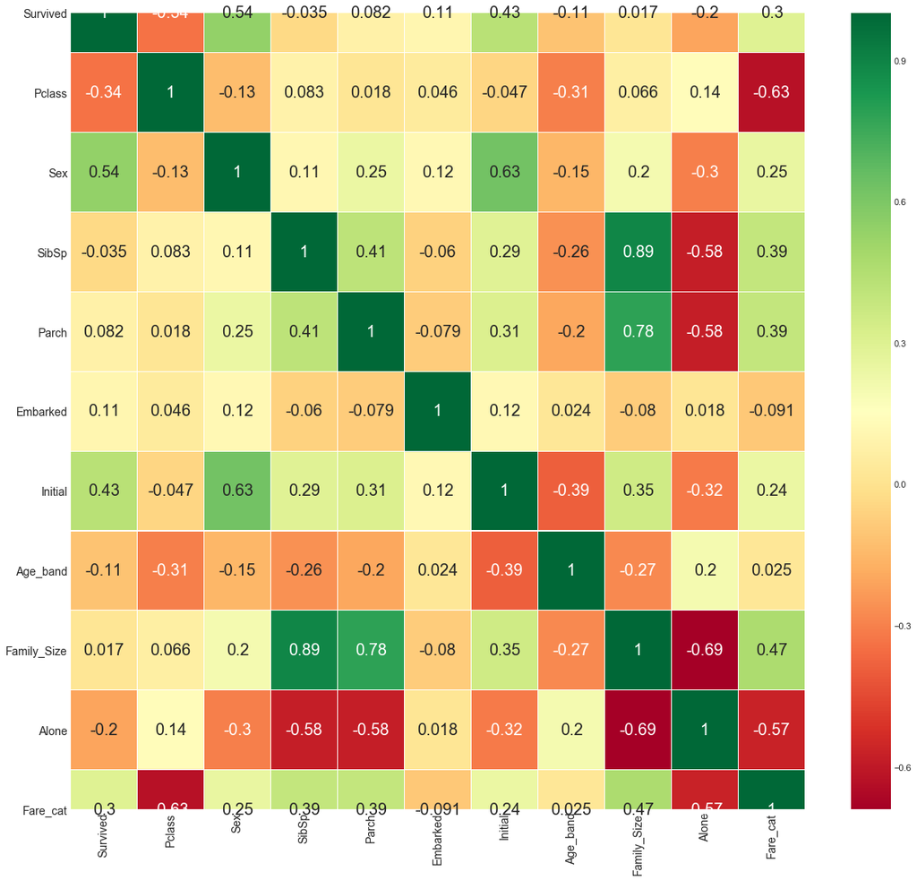

```python
sns.heatmap(df2.corr(),annot=True,cmap='RdYlGn',linewidths=0.2,annot_kws={'size':20})
fig=plt.gcf()
fig.set_size_inches(18,18)
plt.xticks(fontsize=14)
plt.yticks(fontsize=14)
plt.show()
```

```python
df2.info()
```

```
<class 'pandas.core.frame.DataFrame'>
RangeIndex: 891 entries, 0 to 890
Data columns (total 11 columns):
Survived       891 non-null int64
Pclass         891 non-null int64
Sex            891 non-null int64
SibSp          891 non-null int64
Parch          891 non-null int64
Embarked       891 non-null int64
Initial        891 non-null int64
Age_band       891 non-null int64
Family_Size    891 non-null int64
Alone          891 non-null int64
Fare_cat       891 non-null int64
dtypes: int64(11)
memory usage: 76.7 KB
```

```python
dftest2.info()
```

```
<class 'pandas.core.frame.DataFrame'>
RangeIndex: 418 entries, 0 to 417
Data columns (total 10 columns):
Pclass         418 non-null int64
Sex            418 non-null int64
SibSp          418 non-null int64
Parch          418 non-null int64
Embarked       418 non-null int64
Initial        418 non-null int64
Age_band       418 non-null int64
Family_Size    418 non-null int64
Alone          418 non-null int64
Fare_cat       418 non-null int64
dtypes: int64(10)
memory usage: 32.8 KB
```

# Logistic Regression

```python
y = df2['Survived']
X = df2.drop('Survived', axis=1)
```

```python
from sklearn.model_selection import train_test_split
X_train, X_test, y_train, y_test = train_test_split(X, y, test_size=0.2)
```

```python
X_train.head()
```

|  | Pclass | Sex | SibSp | Parch | Embarked | Initial | Age_band | Family_Size | Alone | Fare_cat |
| --- | --- | --- | --- | --- | --- | --- | --- | --- | --- | --- |
| 701 | 1 | 0 | 0 | 0 | 0 | 0 | 2 | 0 | 1 | 2 |
| 44 | 3 | 1 | 0 | 0 | 2 | 2 | 1 | 0 | 1 | 0 |
| 365 | 3 | 0 | 0 | 0 | 0 | 0 | 1 | 0 | 1 | 0 |
| 362 | 3 | 1 | 0 | 1 | 1 | 1 | 2 | 1 | 0 | 2 |
| 471 | 3 | 0 | 0 | 0 | 0 | 0 | 2 | 0 | 1 | 1 |

```python
y_train.head()
```

```
701    1
44     1
365    0
362    0
471    0
Name: Survived, dtype: int64
```

# Logistic Regression with SKLearn

```python
from sklearn.linear_model import LogisticRegression
```

```python
# Fitting Logistic Regression to the Training set

logistic = LogisticRegression(solver='lbfgs')
logistic.fit(X_train, y_train)
```

```
LogisticRegression(C=1.0, class_weight=None, dual=False, fit_intercept=True,
                   intercept_scaling=1, l1_ratio=None, max_iter=100,
                   multi_class='warn', n_jobs=None, penalty='l2',
                   random_state=None, solver='lbfgs', tol=0.0001, verbose=0,
                   warm_start=False)
```

```python
y_pred_test = logistic.predict(X_test)
```

## Confusion Matrxi

```python
from sklearn.metrics import confusion_matrix
```

```python
confusion_matrix
```

```
<function sklearn.metrics.classification.confusion_matrix(y_true, y_pred, labels=None, sample_weight=None)>
```

```python
print(confusion_matrix(y_test, y_pred_test))
```

```
[[94 17]
 [17 51]]
```

```python
# defining our own confusion matrix function
from sklearn.metrics import confusion_matrix
def my_confusion_matrix(y, y_hat):
    cm = confusion_matrix(y, y_hat)
    TN, FP, FN, TP = cm[0,0], cm[0,1], cm[1,0], cm[1,1]
    accuracy = round((TP+TN) / (TP+ FP+ FN+ TN) ,2)
    precision = round( TP / (TP+FP),2)
    recall = round( TP / (TP+FN),2)
    cm_labled = pd.DataFrame(cm, index=['Actual : 0 ','Actual : 1'], columns=['Predict : 0','Predict :1 '])
    print('\n')
    print('Accuracy = {}'.format(accuracy))
    print('Precision = {}'.format(precision))
    print('Recall = {}'.format(recall))
    print("-----------------------------------------")
    return cm_labled
```

```python
my_confusion_matrix(y_test,y_pred_test)
```

```
Accuracy = 0.81
Precision = 0.75
Recall = 0.75
-----------------------------------------
```

|  | Predict : 0 | Predict :1 |
| --- | --- | --- |
| Actual : 0 | 94 | 17 |
| Actual : 1 | 17 | 51 |

## Cross Validation

```python
from sklearn.model_selection import cross_val_score
```

```python
# remember we saved our model in an object called "logistic"
accuracy5 = cross_val_score(estimator = logistic, X = X_train, y = y_train, cv = 5, scoring="accuracy" )

# How do you fix the warning?
```

```python
# remember we saved our model in an object called "logistic"
accuracy10 = cross_val_score(estimator = logistic, X = X_train, y = y_train, cv = 10, scoring="accuracy" )
```

```python
cv = 15
ac = []
for i in range(2,cv+1):
    ac = np.append(ac,np.mean(cross_val_score(estimator = logistic, X = X_train, y = y_train, cv = i, scoring="accuracy")))
```

```python
accuracy5
```

```
array([0.79020979, 0.8041958 , 0.84615385, 0.75352113, 0.82269504])
```

```python
accuracy10
```

```
array([0.76388889, 0.81944444, 0.79166667, 0.83333333, 0.85915493,
       0.83098592, 0.77464789, 0.73239437, 0.77142857, 0.85714286])
```

```python
ls = [2,3,4,5,6,7,8,9,10,11,12,13,14,15]
acc = [accuracy5.mean().round(3),accuracy10.mean().round(3)]
df_acc = pd.DataFrame({"Accuracy":ac},index=ls)
```

```python
df_acc
```

|  | Accuracy |
| --- | --- |
| 2 | 0.793539 |
| 3 | 0.800577 |
| 4 | 0.796318 |
| 5 | 0.803355 |
| 6 | 0.796337 |
| 7 | 0.807521 |
| 8 | 0.803406 |
| 9 | 0.804636 |
| 10 | 0.803409 |
| 11 | 0.806287 |
| 12 | 0.804739 |
| 13 | 0.807575 |
| 14 | 0.801830 |
| 15 | 0.804840 |

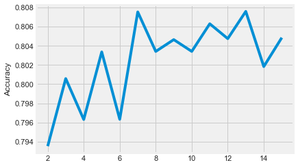

```python
sns.lineplot(x=df_acc.index,y=df_acc['Accuracy'])
```

```python
round(accuracy.mean(),3)
```

```
0.803
```

```python
round(accuracy.std(),3)
```

[output not shown]

```python
print("CV_5 = ",accuracy5.mean().round(3))
```

```
CV_5 =  0.803
```

## **Test Model on Test Data**

```python
yfinal_pred = logistic.predict(dftest2)
```

```python
Y_hat = pd.DataFrame({"Survived":yfinal_pred})
Y_hat.head()
```

|  | Survived |
| --- | --- |
| 0 | 0 |
| 1 | 0 |
| 2 | 0 |
| 3 | 0 |
| 4 | 1 |

```python
X_train.head()
```

|  | Pclass | Sex | SibSp | Parch | Embarked | Initial | Age_band | Family_Size | Alone | Fare_cat |
| --- | --- | --- | --- | --- | --- | --- | --- | --- | --- | --- |
| 701 | 1 | 0 | 0 | 0 | 0 | 0 | 2 | 0 | 1 | 2 |
| 44 | 3 | 1 | 0 | 0 | 2 | 2 | 1 | 0 | 1 | 0 |
| 365 | 3 | 0 | 0 | 0 | 0 | 0 | 1 | 0 | 1 | 0 |
| 362 | 3 | 1 | 0 | 1 | 1 | 1 | 2 | 1 | 0 | 2 |
| 471 | 3 | 0 | 0 | 0 | 0 | 0 | 2 | 0 | 1 | 1 |

```python
final = pd.concat([pd.read_csv('titanic_test.csv')['PassengerId'],Y_hat], axis=1)
```

```python
final.head()
```

|  | PassengerId | Survived |
| --- | --- | --- |
| 0 | 892 | 0 |
| 1 | 893 | 0 |
| 2 | 894 | 0 |
| 3 | 895 | 0 |
| 4 | 896 | 1 |

```python
final
```

|  | PassengerId | Survived |
| --- | --- | --- |
| 0 | 892 | 0 |
| 1 | 893 | 0 |
| 2 | 894 | 0 |
| 3 | 895 | 0 |
| 4 | 896 | 1 |
| ... | ... | ... |
| 413 | 1305 | 0 |
| 414 | 1306 | 1 |
| 415 | 1307 | 0 |
| 416 | 1308 | 0 |
| 417 | 1309 | 0 |

418 rows × 2 columns

```python
final.to_csv("Titanic_Test_Final.csv", index=False)
```

## My Kaggle rank is...9,574!

## Accuracy = 76.55%

### We learned from our cv of 5, that our accuracy of the test set should be around 80%. In our our Kaggle submission, we got an accuracy of 76.55% which is lower than our predicted cv_5.